## 10.5 Problems

1. How can you tell if an object is a tibble? (Hint: try printing mtcars, which is a regular data frame).
   - If you print a tibble it is labled ‘A tibbble’ where as a regular data frame is not labeled
   - tibble prints the first ten rows whereas the data frame prints the whole set

```r
print(mtcars)
```

```
##                      mpg cyl  disp  hp drat    wt  qsec vs am gear carb
## Mazda RX4           21.0   6 160.0 110 3.90 2.620 16.46  0  1    4    4
## Mazda RX4 Wag       21.0   6 160.0 110 3.90 2.875 17.02  0  1    4    4
## Datsun 710          22.8   4 108.0  93 3.85 2.320 18.61  1  1    4    1
## Hornet 4 Drive      21.4   6 258.0 110 3.08 3.215 19.44  1  0    3    1
## Hornet Sportabout   18.7   8 360.0 175 3.15 3.440 17.02  0  0    3    2
## Valiant             18.1   6 225.0 105 2.76 3.460 20.22  1  0    3    1
## Duster 360          14.3   8 360.0 245 3.21 3.570 15.84  0  0    3    4
## Merc 240D           24.4   4 146.7  62 3.69 3.190 20.00  1  0    4    2
## Merc 230            22.8   4 140.8  95 3.92 3.150 22.90  1  0    4    2
## Merc 280            19.2   6 167.6 123 3.92 3.440 18.30  1  0    4    4
## Merc 280C           17.8   6 167.6 123 3.92 3.440 18.90  1  0    4    4
## Merc 450SE          16.4   8 275.8 180 3.07 4.070 17.40  0  0    3    3
## Merc 450SL          17.3   8 275.8 180 3.07 3.730 17.60  0  0    3    3
## Merc 450SLC         15.2   8 275.8 180 3.07 3.780 18.00  0  0    3    3
## Cadillac Fleetwood  10.4   8 472.0 205 2.93 5.250 17.98  0  0    3    4
## Lincoln Continental 10.4   8 460.0 215 3.00 5.424 17.82  0  0    3    4
## Chrysler Imperial   14.7   8 440.0 230 3.23 5.345 17.42  0  0    3    4
## Fiat 128            32.4   4  78.7  66 4.08 2.200 19.47  1  1    4    1
## Honda Civic         30.4   4  75.7  52 4.93 1.615 18.52  1  1    4    2
## Toyota Corolla      33.9   4  71.1  65 4.22 1.835 19.90  1  1    4    1
## Toyota Corona       21.5   4 120.1  97 3.70 2.465 20.01  1  0    3    1
## Dodge Challenger    15.5   8 318.0 150 2.76 3.520 16.87  0  0    3    2
## AMC Javelin         15.2   8 304.0 150 3.15 3.435 17.30  0  0    3    2
## Camaro Z28          13.3   8 350.0 245 3.73 3.840 15.41  0  0    3    4
## Pontiac Firebird    19.2   8 400.0 175 3.08 3.845 17.05  0  0    3    2
## Fiat X1-9           27.3   4  79.0  66 4.08 1.935 18.90  1  1    4    1
## Porsche 914-2       26.0   4 120.3  91 4.43 2.140 16.70  0  1    5    2
## Lotus Europa        30.4   4  95.1 113 3.77 1.513 16.90  1  1    5    2
## Ford Pantera L      15.8   8 351.0 264 4.22 3.170 14.50  0  1    5    4
## Ferrari Dino        19.7   6 145.0 175 3.62 2.770 15.50  0  1    5    6
## Maserati Bora       15.0   8 301.0 335 3.54 3.570 14.60  0  1    5    8
## Volvo 142E          21.4   4 121.0 109 4.11 2.780 18.60  1  1    4    2
```

```r
print(diamonds)
```

```
## # A tibble: 53,940 x 10
##    carat cut       color clarity depth table price     x     y     z
##    <dbl> <ord>     <ord> <ord>   <dbl> <dbl> <int> <dbl> <dbl> <dbl>
##  1 0.23  Ideal     E     SI2      61.5    55   326  3.95  3.98  2.43
##  2 0.21  Premium   E     SI1      59.8    61   326  3.89  3.84  2.31
##  3 0.23  Good      E     VS1      56.9    65   327  4.05  4.07  2.31
##  4 0.290 Premium   I     VS2      62.4    58   334  4.2   4.23  2.63
##  5 0.31  Good      J     SI2      63.3    58   335  4.34  4.35  2.75
##  6 0.24  Very Good J     VVS2     62.8    57   336  3.94  3.96  2.48
##  7 0.24  Very Good I     VVS1     62.3    57   336  3.95  3.98  2.47
##  8 0.26  Very Good H     SI1      61.9    55   337  4.07  4.11  2.53
##  9 0.22  Fair      E     VS2      65.1    61   337  3.87  3.78  2.49
## 10 0.23  Very Good H     VS1      59.4    61   338  4     4.05  2.39
## # … with 53,930 more rows
```

2. Compare and contrast the following operations on a data.frame and equivalent tibble. What is different? Why might the default data frame behaviours cause you frustration?
   - **I am not sure what is going on**

```r
df <- data.frame(abc = 1, xyz = "a")
df$x
```

```
## [1] a
## Levels: a
```

```r
df[, "xyz"]
```

```
## [1] a
## Levels: a
```

```r
df[, c("abc", "xyz")]
```

```
##   abc xyz
## 1   1   a
```

3. Practice referring to non-syntactic names in the following data frame by:
   - Extracting the variable called 1.
   - Plotting a scatterplot of 1 vs 2.
   - Creating a new column called 3 which is 2 divided by 1.
   - Renaming the columns to one, two and three.

```r
annoying <- tibble(
  `1` = 1:10,
  `2` = `1` * 2 + rnorm(length(`1`))
)

annoying$'1'
```

```
##  [1]  1  2  3  4  5  6  7  8  9 10
```

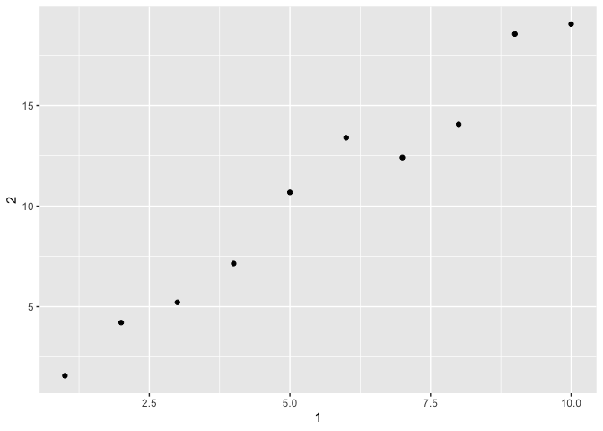

```r
annoying %>% ggplot(aes(x=`1`,y=`2`)) + geom_point()
```

```r
transmute(annoying,
            one = `1`,
            two = `2`,
             three = `2` / `1` )
```

```
## # A tibble: 10 x 3
##      one   two three
##    <int> <dbl> <dbl>
##  1     1  1.57  1.57
##  2     2  4.21  2.10
##  3     3  5.21  1.74
##  4     4  7.14  1.79
##  5     5 10.7   2.14
##  6     6 13.4   2.23
##  7     7 12.4   1.77
##  8     8 14.1   1.76
##  9     9 18.6   2.06
## 10    10 19.0   1.90
```

**I combined 3 and 4 because I couldn’t figure out how to rename**

4. What does tibble::enframe() do? When might you use it?
- Converts vectors into tibbles
  - **I am not sure when you would use it**

```r
enframe(c(a = 5, b = 7))
```

```
## # A tibble: 2 x 2
##   name  value
##   <chr> <dbl>
## 1 a         5
## 2 b         7
```

## 11.2.2 Problems

1. What function would you use to read a file where fields were separated with “|”?

```r
read_delim("1 | 2 | 3 \n a | b | c", delim ="|")
```

```
## # A tibble: 1 x 3
##   `1 `  ` 2 ` ` 3 `
##   <chr> <chr> <chr>
## 1 " a " " b " " c"
```

4. Sometimes strings in a CSV file contain commas. To prevent them from causing problems they need to be surrounded by a quoting character, like " or ’. By default, read_csv() assumes that the quoting character will be ". What argument to read_csv() do you need to specify to read the following text into a data frame?
   - **I am not sure how to group ‘a, b’ into its own column**

```r
read_delim("x,y\n1,'a,b'",delim = "'")
```

```
## # A tibble: 1 x 1
##   `x,y`
##   <dbl>
## 1     1
```

5. Identify what is wrong with each of the following inline CSV files. What happens when you run the code?

```r
read_csv("a,b\n1,2,3\n4,5,6")
```

```
## # A tibble: 2 x 2
##       a     b
##   <dbl> <dbl>
## 1     1     2
## 2     4     5
```

```r
## There are only two columns defined, but there are three values for each row, the last values for each row are dropped

read_csv("a,b,c\n1,2\n1,2,3,4")
```

```
## # A tibble: 2 x 3
##       a     b     c
##   <dbl> <dbl> <dbl>
## 1     1     2    NA
## 2     1     2     3
```

```r
## There are only two values in the first row so there is a "NA" in column c, and the extra value in the second row is dropped

read_csv("a,b\n\"1")
```

```
## # A tibble: 1 x 2
##       a b
##   <dbl> <chr>
## 1     1 <NA>
```

```r
## An extra "? The b column is parsed as a character isnetead of a number and there is a NA in the second column.

read_csv("a,b\n1,2\na,b")
```

```
## # A tibble: 2 x 2
##   a     b
##   <chr> <chr>
## 1 1     2
## 2 a     b
```

```r
## Confusing quotation marks

read_csv("a;b\n1;3")
```

```
## # A tibble: 1 x 1
##   `a;b`
##   <chr>
## 1 1;3
```

```r
## Only one column and one variable described
```

## 11.3.5 Problems

1. What are the most important arguments to locale()?
   - You can define what you used as a decimal point in your data locale = locale(decimal_mark = “,”)
   - You can define grouping marks locale = locale(grouping_mark = “.”)
   - For different languages locale = locale(encoding = “,”)
2. What happens if you try and set decimal_mark and grouping_mark to the same character?
   - There is an error in the locale and it says they must be different

```r
## parse_number("123.456.789", locale = locale(grouping_mark = ".", decimal_mark = "."))
```

- What happens to the default value of grouping_mark when you set decimal_mark to “,”?
  - The grouping mark becomes “.”

```r
 parse_number("123.456.789", locale = locale(decimal_mark = ","))
```

```
## [1] 123456789
```

- What happens to the default value of decimal_mark when you set the grouping_mark to “.”?
  - The decimal mark becomes “,”

```r
parse_number("123.456.789", locale = locale(grouping_mark = "."))
```

```
## [1] 123456789
```

```r
parse_number("123,456,789", locale =locale(grouping_mark = "."))
```

```
## [1] 123.456
```

3. I didn’t discuss the date_format and time_format options to locale(). What do they do? Construct an example that shows when they might be useful.
   - They define how R parses date and time, you can change it to different countries

```r
parse_date("1 janvier 2015", "%d %B %Y", locale = locale("fr"))
```

```
## [1] "2015-01-01"
```

7. Generate the correct format string to parse each of the following dates and times:

```r
d1 <- "January 1, 2010"
parse_date(d1, "%B %d, %Y")
```

```
## [1] "2010-01-01"
```

```r
d2 <- "2015-Mar-07"
parse_date(d2, "%Y-%b-%d")
```

```
## [1] "2015-03-07"
```

```r
d3 <- "06-Jun-2017"
parse_date(d3, "%d-%b-%Y")
```

```
## [1] "2017-06-06"
```

```r
d4 <- c("August 19 (2015)", "July 1 (2015)")
parse_date(d4, "%B %d (%Y)")
```

```
## [1] "2015-08-19" "2015-07-01"
```

```r
d5 <- "12/30/14" # Dec 30, 2014
parse_date(d5, "%m/%d/%y")
```

```
## [1] "2014-12-30"
```

```r
t1 <- "1705"
parse_time(t1, "%H%M")
```

```
## 17:05:00
```

```r
t2 <- "11:15:10.12 PM"
parse_time(t2, "%H:%M:%S %p")
```

```
## 23:15:10
```